IAM chain v4 · run RUN-20261018-04 · 2026-10-18 18:21 UTC

# Sample report: S1_AK0005_buffy_coat_EPICv1

AstroGenetics: the physics of methylation, read on one sample

Specimen buffy coat · platform EPIC

**Research use only. Not a diagnostic test.** Each reading is printed with its commissioning status: *commissioned* means it passed a test sealed before its data was seen; a reading outside what an instrument was tested on is still shown, and says so.

## At a glance

| Instrument | Question it answers | Reading | State | Status |
| --- | --- | --- | --- | --- |
| **IAM-Deconvolver** | Which cells, in what shares | Neutrophils 96.7 %, CD4 T cells 1.2 %, CD8 T cells 0.7 % |  | commissioned (neutrophils, monocytes, CD4 T, CD8 T) |
| **Met-A** | How far the neutrophil's tagging level has moved | A_rel 1.0386 | Normal | This score is preliminary until Met-A is officially commissioned on buffy coat. |
| **C-Score** | Are the departures clustered or scattered | C_rel 1.0669 | not above the band | This score is preliminary until the C-Score is officially commissioned on buffy coat. |
| **IAM-A** | Is each mark still held, against the sample's own reference |  |  | not run (no sequencing input) |

## AstroGenetics: the physics behind each reading

One law runs under every reading here: a mark held against thermal noise costs energy, and the loss of that hold shows as entropy, in bits. Each reading is a ratio to its healthy reference, so healthy reads 1. Its gauge runs from 0, the floor (below it a cell can no longer hold its identity), to saturation, the most the scale can register (every identity site fully scrambled). Both ends are derived from physics, not fitted to data.

[output not shown]

## Cell shares: IAM-Deconvolver against IAM-Atlas v2.1

| Cell |  | Share | Range (information) | Status |
| --- | --- | --- | --- | --- |
| Neutrophils |  | **96.7 %** | 93.9 to 96.9 % | commissioned |
| CD4 T cells |  | **1.2 %** | 0.4 to 2.2 % | commissioned |
| CD8 T cells |  | **0.7 %** | 0.0 to 1.9 % | commissioned |
| B cells |  | **0.6 %** | 0.2 to 1.2 % | This share is preliminary until the IAM-Deconvolver is officially commissioned on B cells. |
| NK cells |  | **0.5 %** | 0.0 to 1.4 % | This share is preliminary until the IAM-Deconvolver is officially commissioned on NK cells. |
| Monocytes |  | **0.2 %** | 0.0 to 2.4 % | commissioned |

Read on 508 of 600 marker sites. Each cell's healthy profile, with its uncertainty and the spread between people, comes from the 79-cell atlas fitted as one model across 21 public sources. Commissioned on mixtures from a laboratory the atlas never saw: median share error 0.016. The ranges are printed as information; they are not calibrated.

## Met-A: the neutrophil's tagging level on the gauge

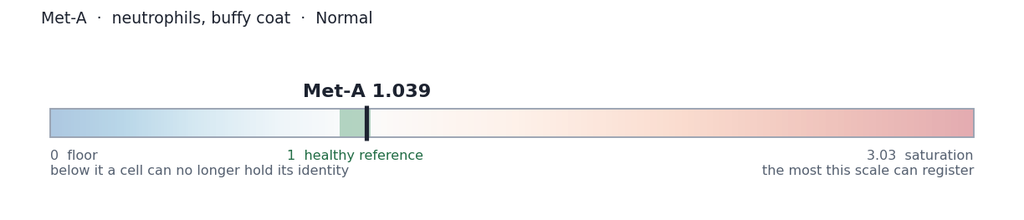

State: **Normal**

This score is preliminary until Met-A is officially commissioned on buffy coat.

## C-Score: clustered or scattered

C_rel 1.0669

This score is preliminary until the C-Score is officially commissioned on buffy coat. not above the band. Healthy reads near 1; above 1.152 is a clustered departure.

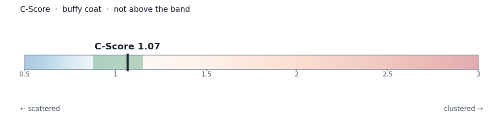

### What changed: the sample laid over its healthy reference

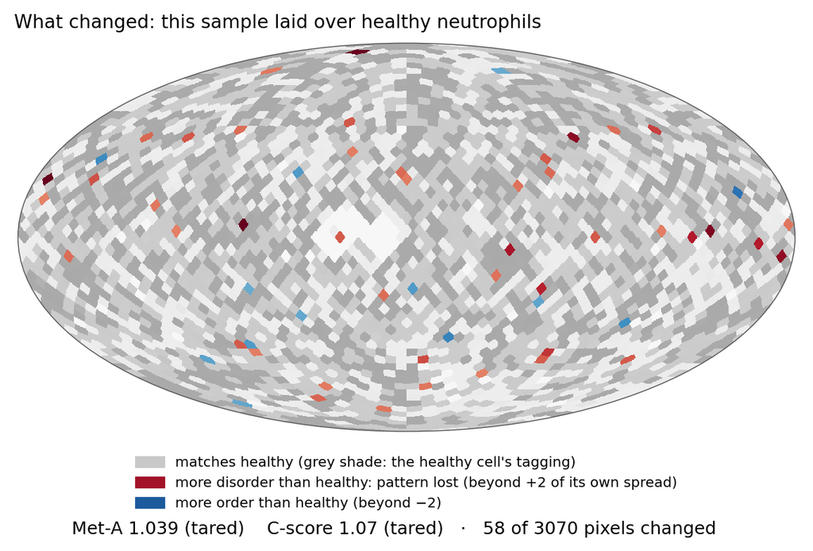

Grey is where this sample matches healthy neutrophils from IAM-Atlas v2.1 (the shade is the healthy cell's own tagging). Color marks only the sites that differ from healthy by more than 2 of this sample's own spread: red where its pattern is more disordered than healthy (marks lost), blue where it is more ordered. Every site keeps one place on a HEALPix sphere, set by its position in the genome, so a few scattered colored points are ordinary, and colored patches are changes that run along the genome, which is what the C-Score measures. A picture of the reading; nothing is scored from it. How sure the healthy reference is at these sites: its 95 % range is half 0.004 wide at the median site (0 would be exact; nine sites in ten within 0.007).

## The readings, in plain words

### Which cells are in the sample

Neutrophils 97 %, CD4 T cells 1 %, CD8 T cells 1 %, B cells 1 %, read against the 79-cell IAM-Atlas v2.1.

### Met-A

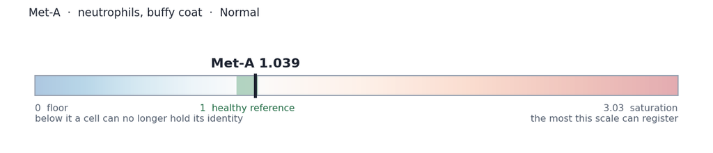

How far the neutrophils' tagging level sits from healthy.

### C-Score

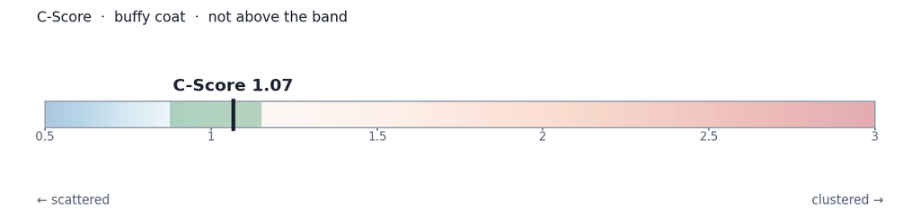

Whether the changes are scattered, as in healthy cells, or clustered along the genome.

### The sample on the sphere

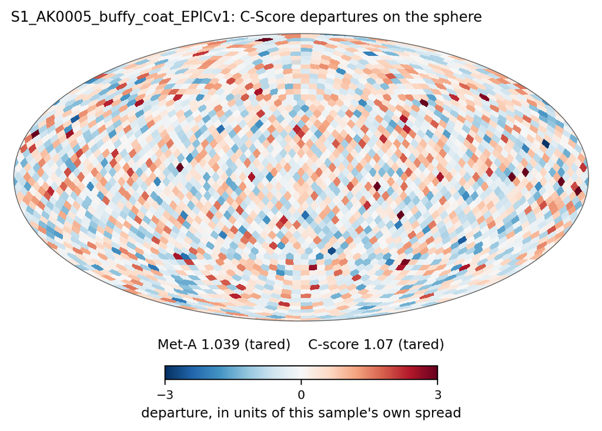

Each dot of color is one place in the genome. Speckle is what healthy looks like; patches mean the changes are bunched together.

## Technical record

**chain v4: Met-A on isolated neutrophils (EPIC v1) COMMISSIONED 2026-10-09; Met-A C-score on whole blood (EPIC v1) COMMISSIONED 2026-10-15; IAM-Deconvolver shares (neutrophils, monocytes, CD4 T, CD8 T; arrays) and IAM-A (healthy CD8 T cells, whole-genome bisulfite) COMMISSIONED 2026-10-17; a reading outside these scopes is printed as preliminary until its instrument is commissioned there**. Not a diagnostic test.

# Cellular Performance Gauge - S1_AK0005_buffy_coat_EPICv1

Run RUN-20261018-04 | specimen: buffy coat | platform EPIC | array type EPIC_v1 | floors metA_floors_v1_3 | reference neutrophil_reference_v1_2

## Stage 0 intake

verdict: **PROCEED** | call rate: PASS 0.99756 | flags: BS_THRESHOLD_UNCALIBRATED

Stage 1 (recorded, not gated): poobah detection DETECTION_BORDERLINE 0.97347 | call rate CALL_RATE_BORDERLINE 0.97219 | controls PROVISIONAL_BS_THRESHOLD_UNCALIBRATED

## Stage 2 composition (8 blood groups)

| NEU | 98.3 % |
| --- | --- |
| B | 1.1 % |

## Stage 5 Met-A - neutrophils

**DEVELOPMENT - not commissioned: buffy coat (read on the whole-blood path; Met-A is commissioned on isolated neutrophils, the C-Score on whole blood)**

**tared: A_rel 1.0386 (Normal)**

**How to read this gauge**

- The gauge reads the writing on the cell's 2D surface, in bits: less writing to the left, more to the right.
- Left end, the floor (H_min): the least writing an X cell can run on. Below it the bit rate is too low to maintain the X cell. Derived: one full ATP per site against thermal kicks.
- Left of healthy: less writing than healthy cells. Senescence reads here.
- Healthy: the balance, the bit rate this cell type is built for. Measured on purified healthy cells, not chosen.
- Right of healthy: more and more writing; the surface fills up toward the full surface, the black-hole side. Cancer sits here. It has not lost its identity; it is writing more than the cell can manage.
- Right end, the ceiling (full surface): every identity site fully scrambled, 1 bit per site, the surface full. Derived.

**A misreading to avoid.** It was made more than three times while this gauge was being built, so it is printed on every report: the gauge reads writing on the surface, not holding energy; left is less writing, right is more. The floor is NOT the most a cell can hold, and cancer does NOT lose its identity. Below the floor the bit rate is too low to maintain the cell; cancer moves right, toward the full surface.

A = **1.0533** (tared: read A_rel (Stage T)); neutrophil fraction 0.9832; sites 5915; composition-matched healthy (EPIC purified group profiles x this specimen's fractions); shift per 1 % loss 0.04967

Methylated sites mean beta 0.9355

## Stage 8 same-run tare

A_rel = **1.0386** Normal | references 3 (median 1.0142) | detection limit: **0.64** % loss of the neutrophil pattern (reference spread 0.0159)

Tare method: step 1 self-tare II (OK), then step 2 median tare (same-run healthy references)

## Stage 9 noise gate

noise index N 0.12201 (48481 of 48528 noise sites) | N_max 0.149 | gate: pass

## Stage 6 Met-A C-score

C = **1.1783** (healthy = 1; healthy held-out range [0.9536771256062556, 1.0455310303870138]); tared C_rel **1.0669** against 3 same-run references; call: **not above the band**; development: specimen outside the commissioned C-score scope

DEVELOPMENT - not commissioned for this specimen

## Withheld

- tier lines beyond Normal (not yet measured on this scale)
- other cell types (outside commissioning scope)

## Red flags

[output not shown]

## Safeguards

| safeguard | result | detail |
| --- | --- | --- |
| rendered-claim scan | PASS | no disease, cohort or population words in the report prose |
| formula self-test | PASS | H(0.5) = 1, H(0.25) = 0.811278, H(0) -> 0; A_rel = A / reference median (agrees); tare state matches the band (yes) |
| anchors | PASS | Normal 0.95-1.05; C-score baseline 1.0103; N_max 0.149 |
| deconvolver conformance | PASS | fractions sum 1.000000, min 0.0000, residual MAE 0.033412829882672135, markers 953 of 963 |
| atlas separability | NOT_RUN | stage 3 (atlas deconvolution) is not wired into this build |

## Troubleshooting

| condition | what to do |
| --- | --- |
| none | no condition on this specimen needs operator action |

## Integrity

| item | sha256 / version |
| --- | --- |
| Grn IDAT | d18e69726f16bfcbd370b9f325cf9a89b0a83a08ee747d91fd586b91d60daada |
| Red IDAT | 62867a0fb3598e3befaf71125af955c4fe28a1ce9ee9bfb75f1a0666a2f648c5 |
| chain commit | de6e20ab |
| methylprep | 1.7.1 |
| python | 3.11.17 |

## Chain file inventory

| file (relative to chain/) | sha256 (12) | bytes |
| --- | --- | --- |
| MethylPhys_Interface/report_v3.py | c03b4897f713 | 31999 |
| MethylPhys_Interface/run_sample.py | 3ed94c31918f | 49880 |
| Runtime Matrices/IAM_A_Positions/hg19_cpg_chrom_ranges.json | fb08d2fbfd15 | 1389 |
| Runtime Matrices/IAM_A_Positions/iama_positions_v2.json | 1bf9bf49b38c | 1807 |
| Runtime Matrices/Intake/intake_thresholds_v1.json | 58f7e6073e8f | 1479 |
| Runtime Matrices/Met_A_Floors/blood_composition_EPIC_v1.json | 6ad3dfb0e01a | 573241 |
| Runtime Matrices/Met_A_Floors/metA_floors_v1_3.json | 2f64f8846f8a | 85068 |
| Runtime Matrices/Met_A_Floors/metA_floors_v1_3_loo.csv | 73f090a7004b | 439 |
| Runtime Matrices/Met_A_Floors/neutrophil_reference_v1_2.json | 820c9b1ecf82 | 944490 |
| Runtime Matrices/Met_A_Floors/noise_gate_EPIC_v1.json | 825f64f7b6c7 | 857 |
| Runtime Matrices/Met_A_Floors/noise_sites_EPIC_v1.json | 353156178326 | 679555 |
| conductor_v3.py | 2d4730ccab67 | 24723 |
| stage_0_1_qc_handoff.py | e91ee9561feb | 9454 |
| stage_0_intake.py | 34c21594dd18 | 51854 |
| stage_1_idat_calibration.py | 75da834dfd53 | 13367 |
| stage_m_met_a.py | 2e8734954dd1 | 4869 |
| stage_q0_intake.py | 1f9b4fca40fe | 9430 |
| stage_q_iam_a.py | 862d596e1b38 | 12211 |

## Run it yourself

From `Biological_Physics/MethylPhys/chain/MethylPhys_Interface` at the chain commit above:

```
python run_sample.py --grn /home/ubuntu/showcase/idat/GSM10113783_207335090090_R05C01_Grn.idat.gz --red /home/ubuntu/showcase/idat/GSM10113783_207335090090_R05C01_Red.idat.gz --specimen "buffy coat" --id S1_AK0005_buffy_coat_EPICv1 --ref-table /home/ubuntu/showcase/out/same_study_refs.csv --out /home/ubuntu/showcase/out/S1_AK0005_buffy_coat_EPICv1.html --ledger /home/ubuntu/showcase/out/ledger.jsonl
```

The frozen inputs are listed in the inventory with their hashes; a reading made from the same IDATs, commit and inputs is identical.

## The chain (SOP v3 section 2b)

[output not shown]

## Toolkit stages

| stage | name | module | status | note |
| --- | --- | --- | --- | --- |
| 3 | Atlas deconvolution (atlas_e, --dev-atlas-e) | chain/dev_stages.py | NOT_RUN | behind a development flag (not given), or not run on this specimen |
| 3b | Trace-cell detection (--dev-trace) | chain/dev_stages.py | NOT_RUN | behind a development flag (not given), or not run on this specimen |
| 3c | Foreign-cell detection (--dev-foreign) | chain/dev_stages.py | NOT_RUN | behind a development flag (not given), or not run on this specimen |
| 4 | NILC component separation (NILC-e, --dev-nilc) | chain/dev_stages.py | NOT_RUN | behind a development flag (not given), or not run on this specimen |
| 10 | Directional decomposition (--dev-direction) | chain/dev_stages.py | NOT_RUN | behind a development flag (not given), or not run on this specimen |
| 11 | Sky map (--dev-sky) | chain/dev_stages.py | NOT_RUN | behind a development flag (not given), or not run on this specimen |
| 11b | Surface brightness (--dev-brightness) | chain/dev_stages.py | NOT_RUN | behind a development flag (not given), or not run on this specimen |
| 12 | Sky statistics (--dev-sky) | chain/sky_statistics.py | NOT_RUN | behind a development flag (not given), or not run on this specimen |
| 12b | Difference map | chain/serial_mode.py | NOT_RUN | built; not run on this specimen |
| 12 | apodised mask | - | NOT_BUILT | listed under stage 12 as a tool to build |
| 12 | beam smoothing | - | NOT_BUILT | listed under stage 12 as a tool to build |
| 12 | cell-type covariance in the separation (GLS) | - | NOT_BUILT | listed under stage 12 as a tool to build |
| 12 | Fisher degeneracy of the composition | - | NOT_BUILT | listed under stage 12 as a tool to build |
| 12 | ILC on the residual sky | - | NOT_BUILT | listed under stage 12 as a tool to build |
| 12 | per-specimen composition posterior | - | NOT_BUILT | listed under stage 12 as a tool to build |
| 12 | cross-spectra between cell panels | - | NOT_BUILT | listed under stage 12 as a tool to build |
| 12 | difference map drawn as a sky | - | NOT_BUILT | listed under stage 12 as a tool to build |

**bundle (JSON, also written beside this page)**

[output not shown]